# Estimacion ARIMA

Miguel G.

27/10/2022

# ACF y PACF de una serie

Vamos analizar las series de tiempo del ejercio de raiz unitaria, cargamos los datos de la manera estandar:

```r
rm(list=ls())

setwd("C:/Users/Miike/OneDrive - ITESO/01 Documentos/O2022/pronosticos/arima")

library(tseries)
library(forecast)
library(tidyverse)
library(readxl)
library(lmtest)

oil <- read_excel("series_macroeconomicas.xlsx", sheet="dt_oil")

oil <- ts(oil$oil_brent, start = c(1987,5), frequency = 12)
```

Graficamos la serie

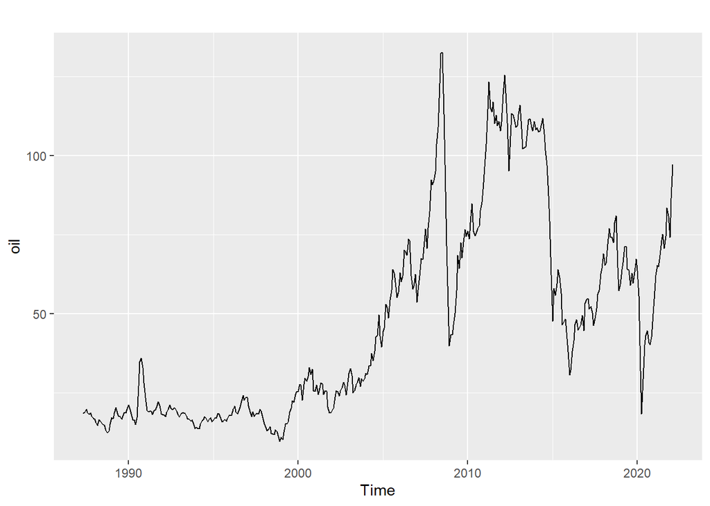

```r
autoplot(oil)
```

Según los resultados de la tarea anterior, esta serie es integrada de orden 1.

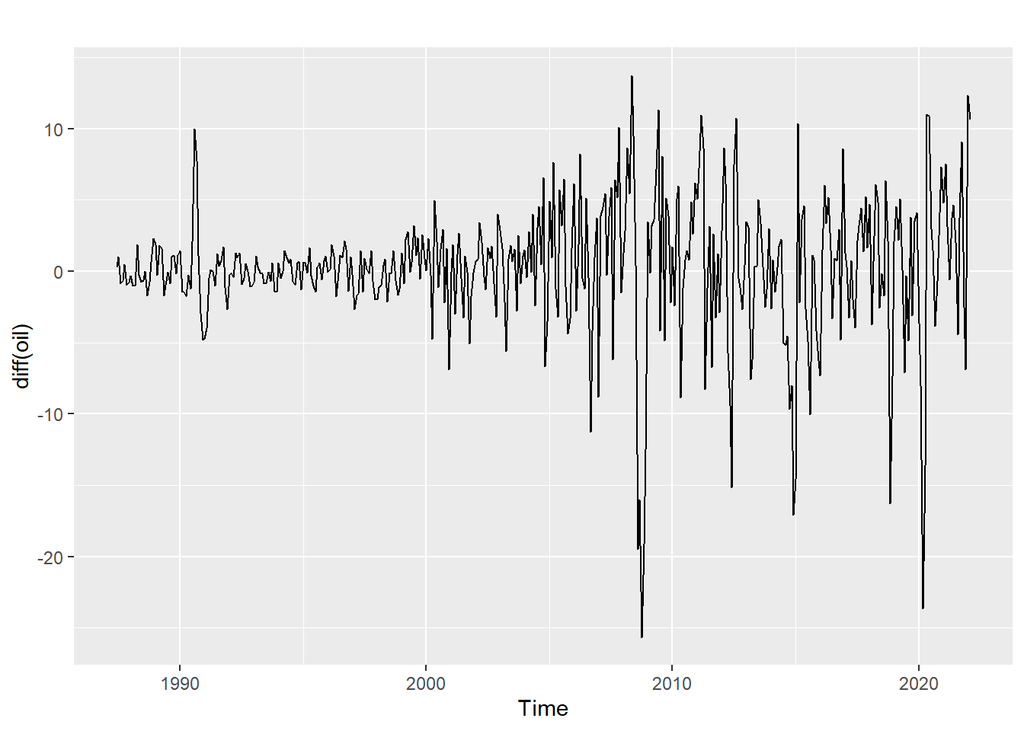

```r
autoplot(diff(oil))
```

Vamos analizar la ACF y PACF para proponer un modelo tentativo.

Recuerda que **debemos calcular la ACF y PACF para la serie estacionaria**, es decir, para la serie en primeras diferencias.

La función *tsdisplay()* muestra una grafica de la serie, la ACF y la PACF.

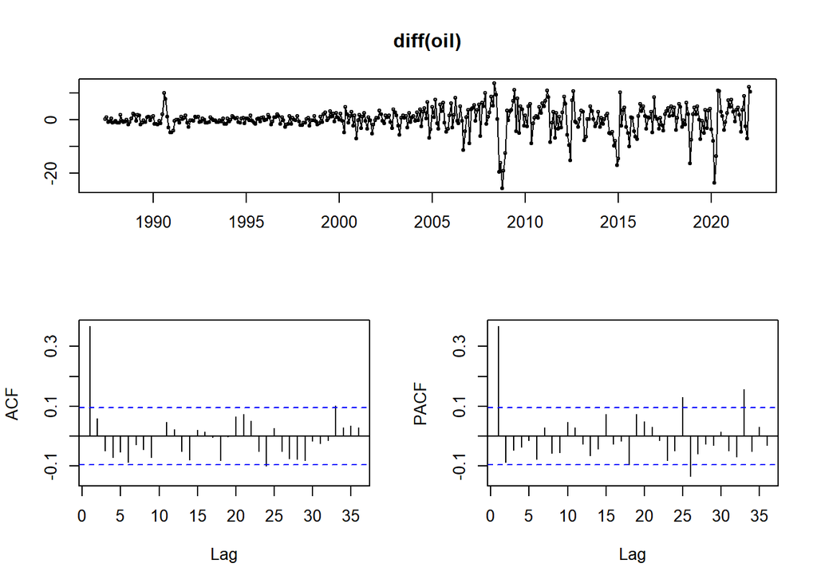

```r
tsdisplay(diff(oil))
```

El primer modelo tentativo según el comportamiendo de las funciones de autocorrelacion es un $ARIMA(p,d,q)=ARIMA (1,1,1)$

Si quisiera calcular sola ACF

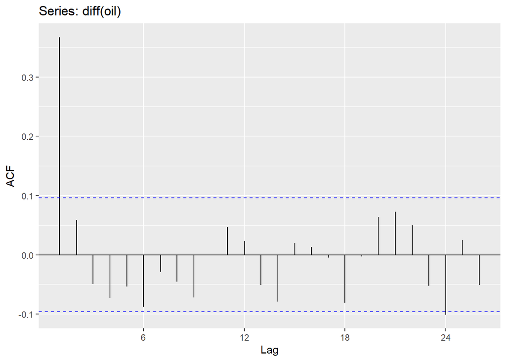

```r
ggAcf(diff(oil))
```

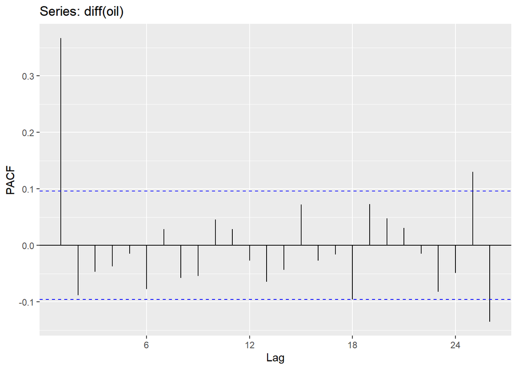

```r
ggPacf(diff(oil))
```

# Estimacion

Vamos a estimar el modelo $ARIMA(1,1,1)$

El modelo lo podemos estimar con o sin constante.

```r
# modelo tentativo 1 ARIMA(1,1,1) con constante
modelo_1 <- Arima(oil, order = c(1,1,1), include.constant = TRUE)

# modelo tentativo 2 ARIMA(1,1,1) sin constante
modelo_2 <- Arima(oil, order = c(1,1,1), include.constant = FALSE)

# modelo tentativo 3 ARIMA(0,1,1) con constante
modelo_3 <- Arima(oil, order = c(0,1,1), include.constant = TRUE)

# modelo tentativo 4 ARIMA(0,1,1) sin constante
modelo_4 <- Arima(oil, order = c(0,1,1), include.constant = FALSE)

# modelo tentativo 5 ARIMA(1,1,0) con constante
modelo_5 <- Arima(oil, order = c(1,1,0), include.constant = TRUE)

# modelo tentativo 6 ARIMA(1,1,0) sin constante
modelo_6 <- Arima(oil, order = c(1,1,0), include.constant = FALSE)
```

Necesitamos analizar cual es el mejor modelo:

Primero seleccionamos el modelo con el menor criterio de información

```r
modelo_1$bic
```

```
## [1] 2454.346
```

```r
modelo_2$bic
```

```
## [1] 2448.676
```

```r
modelo_3$bic
```

```
## [1] 2451.283
```

```r
modelo_4$bic
```

```
## [1] 2445.665
```

```r
modelo_5$bic
```

```
## [1] 2450.683
```

```r
modelo_6$bic
```

```
## [1] 2444.991
```

El criterio de información indica que el modelo 6 tiene el menor valor.

Analizamos al significancia del coeficiente estimado, con una prueba de hipotesis

```r
coeftest(modelo_6)
```

```
##
## z test of coefficients:
##
##     Estimate Std. Error z value  Pr(>|z|)
## ar1 0.371377   0.045671  8.1316 4.237e-16 ***
## ---
## Signif. codes:  0 '***' 0.001 '**' 0.01 '*' 0.05 '.' 0.1 ' ' 1
```

```r
coeftest(modelo_4)
```

```
##
## z test of coefficients:
##
##     Estimate Std. Error z value  Pr(>|z|)
## ma1 0.366333   0.042529  8.6136 < 2.2e-16 ***
## ---
## Signif. codes:  0 '***' 0.001 '**' 0.01 '*' 0.05 '.' 0.1 ' ' 1
```

Analizamos la autocorrelación de los residuales para verificar si son ruido blanco o no:

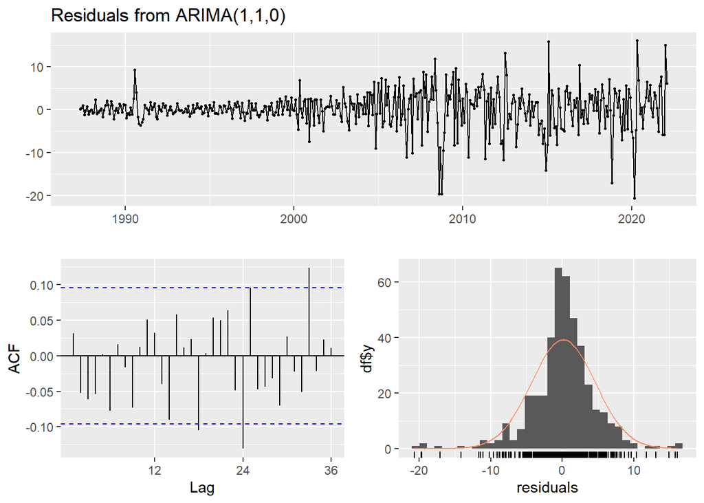

```
##
##  Ljung-Box test
##
## data:  Residuals from ARIMA(1,1,0)
## Q* = 34.913, df = 23, p-value = 0.05306
##
## Model df: 1.   Total lags used: 24
```

```r
checkresiduals(modelo_6)
```

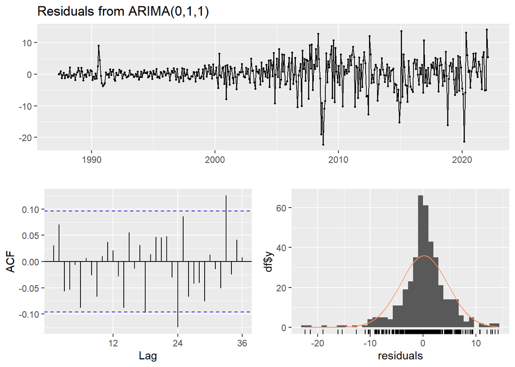

```
##
##  Ljung-Box test
##
## data:  Residuals from ARIMA(0,1,1)
## Q* = 31.714, df = 23, p-value = 0.1062
##
## Model df: 1.   Total lags used: 24
```

```r
checkresiduals(modelo_4)
```

pronosticamos los siguientes 10 periodos

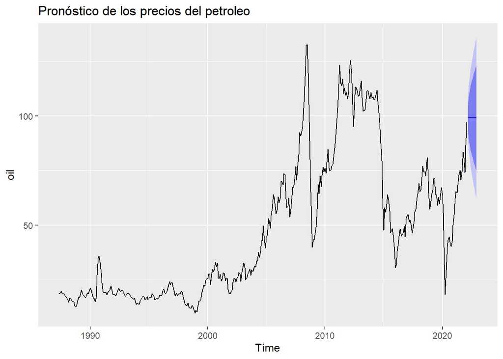

```r
pronostico <- forecast(modelo_4, 10)

autoplot(pronostico)+
  ggtitle("Pronóstico de los precios del petroleo")
```

## Transformación logaritma

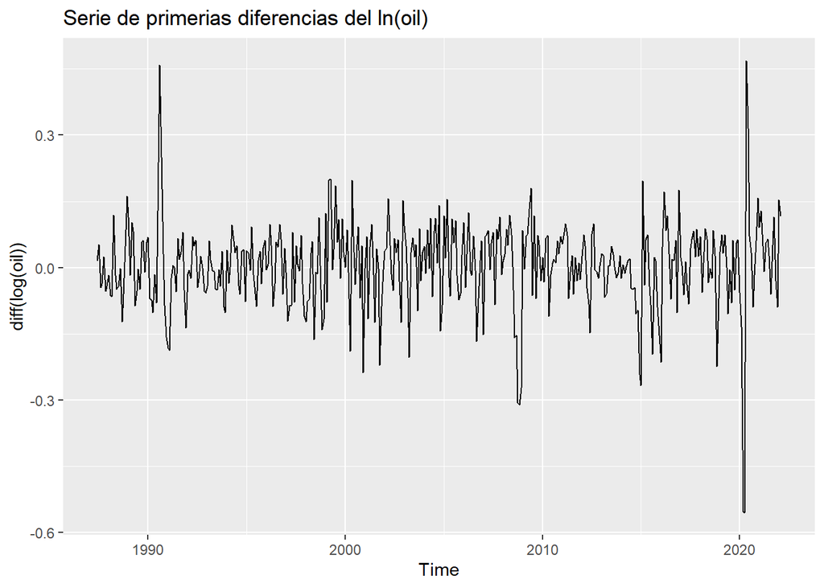

```r
autoplot(diff(log(oil)))+
  ggtitle("Serie de primerias diferencias del ln(oil)")
```

Modelo arima con trasformación logaritmica de un ARIMA(0,1,1) sin constante

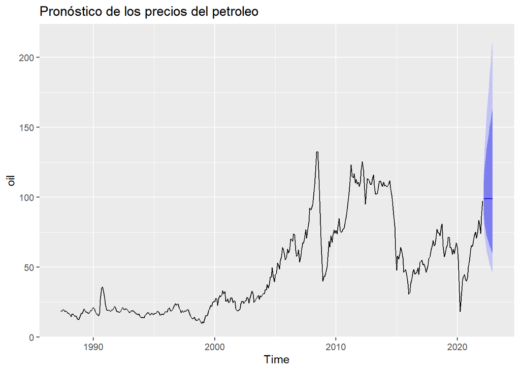

```r
modelo_4_ln <- Arima(oil, order=c(0,1,1), include.constant = F, lambda = 0)

pronostico2 <- forecast(modelo_4_ln, 10)

autoplot(pronostico2)+
  ggtitle("Pronóstico de los precios del petroleo")
```